# HW2: Data Import, Cleaning, and Exploration

Author

Carmen Marshall

Published

October 6, 2026

The PalmTraits 1.0 dataset comes from a paper compiling a species-level function trait database of palms worldwide. Downloaded as a public dataset from Dryad. Locally, comes from the data subfolder of HW2 folder, which is in week2.

```r
library(dplyr)
```

## Part 1: Import and First Look

```r
# 1.1 Import the data
palm_data <- read.delim("data/PalmTraits_1.0.txt", header = TRUE,
     stringsAsFactors = FALSE)
# showing the structure of the palm data
dim(palm_data)
```

```
[1] 2557   29
```

```r
names(palm_data)
```

```
 [1] "SpecName"              "accGenus"              "accSpecies"
 [4] "PalmTribe"             "PalmSubfamily"         "Climbing"
 [7] "Acaulescent"           "Erect"                 "StemSolitary"
[10] "StemArmed"             "LeavesArmed"           "MaxStemHeight_m"
[13] "MaxStemDia_cm"         "UnderstoreyCanopy"     "MaxLeafNumber"
[16] "Max_Blade_Length_m"    "Max_Rachis_Length_m"   "Max_Petiole_length_m"
[19] "AverageFruitLength_cm" "MinFruitLength_cm"     "MaxFruitLength_cm"
[22] "AverageFruitWidth_cm"  "MinFruitWidth_cm"      "MaxFruitWidth_cm"
[25] "FruitSizeCategorical"  "FruitShape"            "FruitColorDescription"
[28] "MainFruitColors"       "Conspicuousness"
```

```r
head(palm_data, 5)
```

```
                  SpecName       accGenus accSpecies     PalmTribe
1   Acanthophoenix crinita Acanthophoenix    crinita       Areceae
2 Acanthophoenix rousselii Acanthophoenix  rousselii       Areceae
3     Acanthophoenix rubra Acanthophoenix      rubra       Areceae
4   Acoelorrhaphe wrightii  Acoelorrhaphe   wrightii Trachycarpeae
5       Acrocomia aculeata      Acrocomia   aculeata      Cocoseae
  PalmSubfamily Climbing Acaulescent Erect StemSolitary StemArmed LeavesArmed
1    Arecoideae        0           0     1            1         1           1
2    Arecoideae        0           0     1            1         1           1
3    Arecoideae        0           0     1            1         1           1
4  Coryphoideae        0           0     1            0         0           1
5    Arecoideae        0           0     1            1         1           1
  MaxStemHeight_m MaxStemDia_cm UnderstoreyCanopy MaxLeafNumber
1            10.0            20            canopy            15
2            25.0            30            canopy            NA
```

[output cut: 27 more lines]

```r
str(palm_data)
```

```
'data.frame':   2557 obs. of  29 variables:
 $ SpecName             : chr  "Acanthophoenix crinita" "Acanthophoenix rousselii" "Acanthophoenix rubra" "Acoelorrhaphe wrightii" ...
 $ accGenus             : chr  "Acanthophoenix" "Acanthophoenix" "Acanthophoenix" "Acoelorrhaphe" ...
 $ accSpecies           : chr  "crinita" "rousselii" "rubra" "wrightii" ...
 $ PalmTribe            : chr  "Areceae" "Areceae" "Areceae" "Trachycarpeae" ...
 $ PalmSubfamily        : chr  "Arecoideae" "Arecoideae" "Arecoideae" "Coryphoideae" ...
 $ Climbing             : int  0 0 0 0 0 0 0 0 0 0 ...
 $ Acaulescent          : int  0 0 0 0 0 0 1 0 1 0 ...
 $ Erect                : int  1 1 1 1 1 1 0 1 0 1 ...
 $ StemSolitary         : int  1 1 1 0 1 1 1 1 1 1 ...
 $ StemArmed            : int  1 1 1 0 1 1 1 1 1 1 ...
 $ LeavesArmed          : int  1 1 1 1 1 1 1 1 1 1 ...
 $ MaxStemHeight_m      : num  10 25 15 9.1 12 18 0 NA 0 NA ...
 $ MaxStemDia_cm        : num  20 30 18 15 50 35 NA NA NA NA ...
 $ UnderstoreyCanopy    : chr  "canopy" "canopy" "canopy" "canopy" ...
 $ MaxLeafNumber        : int  15 NA 20 25 30 15 NA NA 6 NA ...
 $ Max_Blade_Length_m   : num  2.3 3 3.1 1.3 3.5 3 NA NA 0.9 NA ...
 $ Max_Rachis_Length_m  : num  NA NA 3 0.7 2.5 NA NA NA 0.54 NA ...
 $ Max_Petiole_length_m : num  NA NA NA 0.65 NA 0.65 NA NA 0.51 NA ...
 $ AverageFruitLength_cm: num  0.65 2 1 0.7 4.25 2.5 2 NA 2.25 4.6 ...
 $ MinFruitLength_cm    : num  0.6 NA NA NA 3.5 NA NA NA 1.5 3.8 ...
 $ MaxFruitLength_cm    : num  0.7 NA NA NA 5 NA NA NA 3 5.4 ...
 $ AverageFruitWidth_cm : num  0.5 0.8 0.7 0.7 4.6 1.8 2 NA 2.25 4.6 ...
 $ MinFruitWidth_cm     : num  NA NA NA 0.5 3.8 NA NA NA 1.5 3.8 ...
 $ MaxFruitWidth_cm     : num  NA NA NA 0.9 5.4 NA NA NA 3 5.4 ...
 $ FruitSizeCategorical : chr  "small" "small" "small" "small" ...
 $ FruitShape           : chr  "" "ovoid" "ovoid" "ovoid" ...
 $ FruitColorDescription: chr  "black" "black" "black" "orange-brown; becomming black" ...
 $ MainFruitColors      : chr  "black" "black" "black" "brown; black" ...
 $ Conspicuousness      : chr  "cryptic" "cryptic" "cryptic" "cryptic" ...
```

There are 2557 rows and 29 columns, meaning 2557 species and 29 variables. The variables in text are Species Name, Genus, Species, Tribe, SubFamily, Understory/Canopy, Fruit size, fruit shape, fruit color description, main fruit colors, and conspicuousness. This leaves the rest of the variables, such as max stem height and max blade length, as numbers.

# 1.2

```r
# 1.2 Guided exploration in the data explorer / confirming a) and b) with code
palm_data$SpecName[which.max(palm_data$MaxStemHeight_m)]
```

```
[1] "Calamus manan"
```

```r
sum(palm_data$Climbing == 1)
```

```
[1] 530
```

```r
table(palm_data$UnderstoreyCanopy) #shows 265 empty values
```

```
                   both      canopy understorey
        265          14        1334         944
```

## Part 2: Data Cleaning with Base R

```r
# 2.1 Find the missing values
# missing values in the whole dataset, and per column
sum(is.na(palm_data))
```

```
[1] 13359
```

```r
colSums(is.na(palm_data))
```

```
             SpecName              accGenus            accSpecies
                    0                     0                     0
            PalmTribe         PalmSubfamily              Climbing
                    0                     0                     0
          Acaulescent                 Erect          StemSolitary
                    0                     0                   375
            StemArmed           LeavesArmed       MaxStemHeight_m
                   55                   120                   446
        MaxStemDia_cm     UnderstoreyCanopy         MaxLeafNumber
                  602                     0                  1251
   Max_Blade_Length_m   Max_Rachis_Length_m  Max_Petiole_length_m
                  659                  1026                  1347
AverageFruitLength_cm     MinFruitLength_cm     MaxFruitLength_cm
                  505                  1651                  1641
 AverageFruitWidth_cm      MinFruitWidth_cm      MaxFruitWidth_cm
                  563                  1563                  1555
 FruitSizeCategorical            FruitShape FruitColorDescription
                    0                     0                     0
      MainFruitColors       Conspicuousness
                    0                     0
```

```r
# Percentage missing per column, sorted
pct_missing <- round(100 * colMeans(is.na(palm_data)), 1)
sort(pct_missing, decreasing = TRUE)
```

```
    MinFruitLength_cm     MaxFruitLength_cm      MinFruitWidth_cm
                 64.6                  64.2                  61.1
     MaxFruitWidth_cm  Max_Petiole_length_m         MaxLeafNumber
                 60.8                  52.7                  48.9
  Max_Rachis_Length_m    Max_Blade_Length_m         MaxStemDia_cm
                 40.1                  25.8                  23.5
 AverageFruitWidth_cm AverageFruitLength_cm       MaxStemHeight_m
                 22.0                  19.7                  17.4
         StemSolitary           LeavesArmed             StemArmed
                 14.7                   4.7                   2.2
             SpecName              accGenus            accSpecies
                  0.0                   0.0                   0.0
            PalmTribe         PalmSubfamily              Climbing
                  0.0                   0.0                   0.0
          Acaulescent                 Erect     UnderstoreyCanopy
                  0.0                   0.0                   0.0
 FruitSizeCategorical            FruitShape FruitColorDescription
                  0.0                   0.0                   0.0
      MainFruitColors       Conspicuousness
                  0.0                   0.0
```

```r
# Duplicated rows
sum(duplicated(palm_data))
```

```
[1] 0
```

Fruit trait data seem to have the most missing data, with Fruit Length and Width data having the highest percentage of missing values.The output of sum(duplicated(palm_data)) was 0 (or FALSE), indicating that there are no duplicate rows.

```r
# 2.2 Create a working subset
keep <- c("SpecName", "Climbing", "Acaulescent", "Erect", "StemArmed",
           "MaxStemHeight_m", "Max_Blade_Length_m",
           "AverageFruitLength_cm", "AverageFruitWidth_cm")
palm_subset <- palm_data[, keep]
dim(palm_subset)
```

```
[1] 2557    9
```

This subset of the data now has 9 variables and still 2557 rows/observations.

```r
# 2.3 Handle missing values
key_vars <- c("MaxStemHeight_m", "AverageFruitLength_cm")
palm_clean <- palm_subset[complete.cases(palm_subset[, key_vars]), ]
nrow(palm_subset) - nrow(palm_clean)   # how many rows were removed?
```

```
[1] 650
```

```r
colSums(is.na(palm_clean))             # what is still missing?
```

```
             SpecName              Climbing           Acaulescent
                    0                     0                     0
                Erect             StemArmed       MaxStemHeight_m
                    0                    17                     0
   Max_Blade_Length_m AverageFruitLength_cm  AverageFruitWidth_cm
                  199                     0                    54
```

```r
# 2.4 Fix data types
str(palm_clean$StemArmed)
```

```
 int [1:1907] 1 1 1 0 1 1 1 1 0 0 ...
```

```r
palm_clean$StemArmed <- factor(palm_clean$StemArmed,levels = c(0, 1),
     labels = c("Unarmed", "Armed"))
table(palm_clean$StemArmed, useNA = "ifany") # 1705 unarmed, 185 armed, 17 NA
```

```
Unarmed   Armed    <NA>
   1705     185      17
```

```r
# fix data type for Climbing
palm_clean$Climbing <- factor(palm_clean$Climbing, levels = c(0, 1, 2),
     labels = c("No", "Yes", "Both"))
table(palm_clean$Climbing, useNA = "ifany")
```

```
  No  Yes Both
1583  310   14
```

```r
str(palm_clean)
```

```
'data.frame':   1907 obs. of  9 variables:
 $ SpecName             : chr  "Acanthophoenix crinita" "Acanthophoenix rousselii" "Acanthophoenix rubra" "Acoelorrhaphe wrightii" ...
 $ Climbing             : Factor w/ 3 levels "No","Yes","Both": 1 1 1 1 1 1 1 1 1 1 ...
 $ Acaulescent          : int  0 0 0 0 0 0 1 1 0 0 ...
 $ Erect                : int  1 1 1 1 1 1 0 0 1 1 ...
 $ StemArmed            : Factor w/ 2 levels "Unarmed","Armed": 2 2 2 1 2 2 2 2 1 1 ...
 $ MaxStemHeight_m      : num  10 25 15 9.1 12 18 0 0 9 9 ...
 $ Max_Blade_Length_m   : num  2.3 3 3.1 1.3 3.5 3 NA 0.9 2.35 1.2 ...
 $ AverageFruitLength_cm: num  0.65 2 1 0.7 4.25 2.5 2 2.25 2.6 3 ...
 $ AverageFruitWidth_cm : num  0.5 0.8 0.7 0.7 4.6 1.8 2 2.25 1.1 1.3 ...
```

It matters that these variables are factors instead of numbers because if we were to calculate summaries for these variables, they would calculate,for example, the mean of a bunch of 0s, 1s, and 2s, calculating a mean of a variable that doesn’t have an average since it’s not a measurement. We would want to get counts of how many species have a level of the factor, not numerical calculated summaries.

```r
# 2.5 Create new variables
# Part a: make a size category from stem height
palm_clean$size_category <- ifelse(palm_clean$MaxStemHeight_m <= 5, "Small",
                            ifelse(palm_clean$MaxStemHeight_m <= 15, "Medium",
                            ifelse(palm_clean$MaxStemHeight_m <= 30, "Tall", "Very Tall")))
palm_clean$size_category <- factor(palm_clean$size_category,
                                  levels = c("Small", "Medium", "Tall", "Very Tall"))
table(palm_clean$size_category) # 837 small, 621 medium, 351 tall, 98 very tall
```

```
    Small    Medium      Tall Very Tall
      837       621       351        98
```

```r
# Part b: make fruit aspect ratio
fruit_ratio <- palm_clean$AverageFruitLength_cm / palm_clean$AverageFruitWidth_cm
summary(fruit_ratio, na.rm = TRUE)
```

```
   Min. 1st Qu.  Median    Mean 3rd Qu.    Max.     NAs
 0.1385  1.0000  1.3333  1.4661  1.6667  6.7500      54
```

A ratio of above 1 means that for the given species, the average fruit length is larger than the same species’ average fruit width. There are 54 NA values because those given species either do not have data for Avg Fruit Length or Width or both available to calculate the ratio.

## Part 3: Descriptive Statistics

```r
# 3.1 Summary Statistics
# summary stats for max stem height
max_stem_height <- palm_clean$MaxStemHeight_m
mean(max_stem_height)
```

```
[1] 11.20294
```

```r
median(max_stem_height)
```

```
[1] 7
```

```r
sd(max_stem_height)
```

```
[1] 12.91322
```

```r
quantile(max_stem_height, probs = c(0, 0.25, 0.5, 0.75, 1))
```

```
  0%  25%  50%  75% 100%
   0    3    7   15  170
```

```r
# summary stats for average fruit length
avg_fruit_length <- palm_clean$AverageFruitLength_cm
mean(avg_fruit_length)
```

```
[1] 2.195507
```

```r
median(avg_fruit_length)
```

```
[1] 1.5
```

```r
sd(avg_fruit_length)
```

```
[1] 2.275187
```

```r
quantile(avg_fruit_length, probs = c(0, 0.25, 0.5, 0.75, 1))
```

```
   0%   25%   50%   75%  100%
 0.40  1.05  1.50  2.50 45.00
```

```r
data.frame1 <- data.frame(Mean = c(mean(max_stem_height), mean(avg_fruit_length)),
     Median = c(median(max_stem_height), median(avg_fruit_length)),
     SD = c(sd(max_stem_height), sd(avg_fruit_length)),
     First.Quantile = c(quantile(max_stem_height, probs = 0.25), quantile(avg_fruit_length, probs = 0.25)),
     Third.Quantile = c(quantile(max_stem_height, probs = 0.75), quantile(avg_fruit_length, probs = 0.75)))
rownames(data.frame1) <- c("Max Stem Height", "Average Fruit Length")
print(data.frame1)
```

```
                          Mean Median        SD First.Quantile Third.Quantile
Max Stem Height      11.202937    7.0 12.913217           3.00           15.0
Average Fruit Length  2.195507    1.5  2.275187           1.05            2.5
```

```r
# 3.2 Frequency tables
table(palm_clean$size_category)
```

```
    Small    Medium      Tall Very Tall
      837       621       351        98
```

```r
prop.table(table(palm_clean$size_category))
```

```
     Small     Medium       Tall  Very Tall
0.43890928 0.32564237 0.18405873 0.05138962
```

```r
# Two-way table: size category vs armature, with row proportions
tab <- table(palm_clean$size_category, palm_clean$StemArmed)
tab
```

```
            Unarmed Armed
  Small         764    64
  Medium        537    77
  Tall          316    34
  Very Tall      88    10
```

```r
round(prop.table(tab, margin = 1), 2)
```

```
            Unarmed Armed
  Small        0.92  0.08
  Medium       0.87  0.13
  Tall         0.90  0.10
  Very Tall    0.90  0.10
```

Medium height palms have the highest proportion of armed palms, about 13%.

```r
# 3.3: Group summaries with dplyr
palm_clean %>%
   group_by(StemArmed) %>%
   summarize(n = n(),
   mean_height = mean(MaxStemHeight_m),
   sd_height = sd(MaxStemHeight_m),
   median_fruit_length = median(AverageFruitLength_cm))
```

```
# A tibble: 3 × 5
  StemArmed     n mean_height sd_height median_fruit_length
  <fct>     <int>       <dbl>     <dbl>               <dbl>
1 Unarmed    1705       11.2      13.1                 1.5
2 Armed       185       12.0      11.5                 1.65
3 <NA>         17        6.59      5.84                2.5
```

```r
# group summary by size category + add maximum of max stem height
palm_summary <- palm_clean %>%
    group_by(size_category) %>%
    summarize(n = n(),
     mean_height2 = mean(MaxStemHeight_m),
     sd_height2 = sd(MaxStemHeight_m),
     median_fruit_length2 = median(AverageFruitLength_cm),
     max_height = max(MaxStemHeight_m))
print(palm_summary)
```

```
# A tibble: 4 × 6
  size_category     n mean_height2 sd_height2 median_fruit_length2 max_height
  <fct>         <int>        <dbl>      <dbl>                <dbl>      <dbl>
1 Small           837         2.38       1.61                 1.3           5
2 Medium          621        10.4        3.24                 1.7          15
3 Tall            351        23.0        4.36                 1.8          30
4 Very Tall        98        49.4       21.6                  1.88        170
```

This summary shows, as expected, that the Very Tall palms have the largest mean height as well as the largest maximum height. We can also infer from the table that as trees are taller, the median fruit length increases as well.

## Part 4: Visualizations with Base R

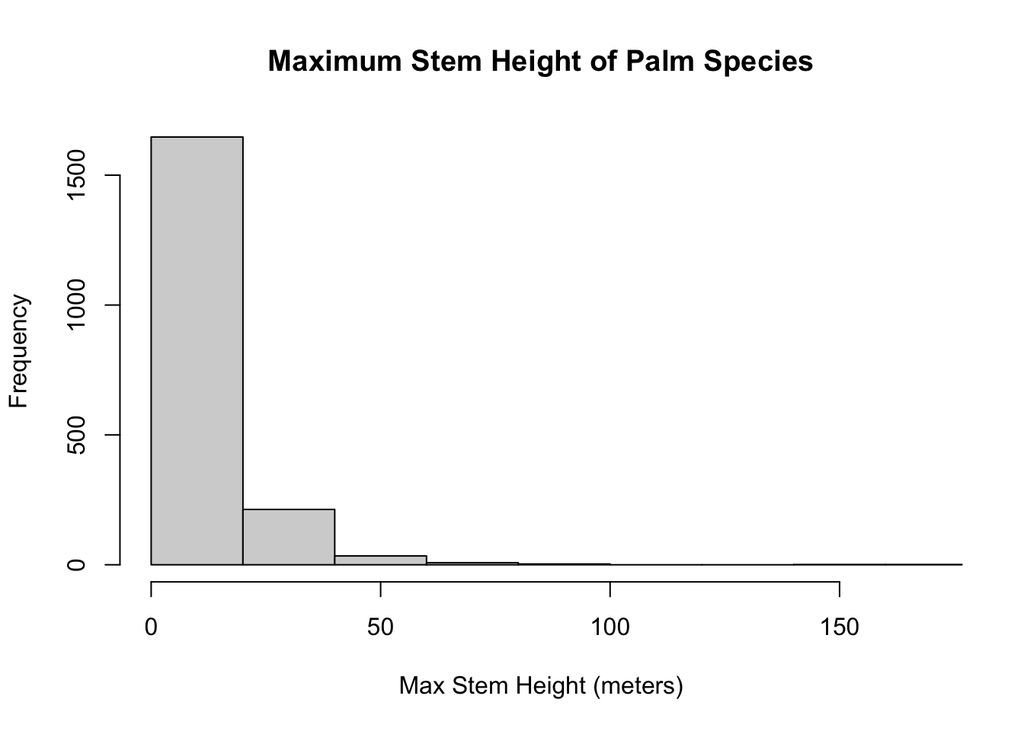

```r
# 4.1 Histogram of stem height
hist(palm_clean$MaxStemHeight_m, main = paste("Maximum Stem Height of Palm Species"),
    xlim = c(0, 170), xlab = "Max Stem Height (meters)", ylab = "Frequency")
```

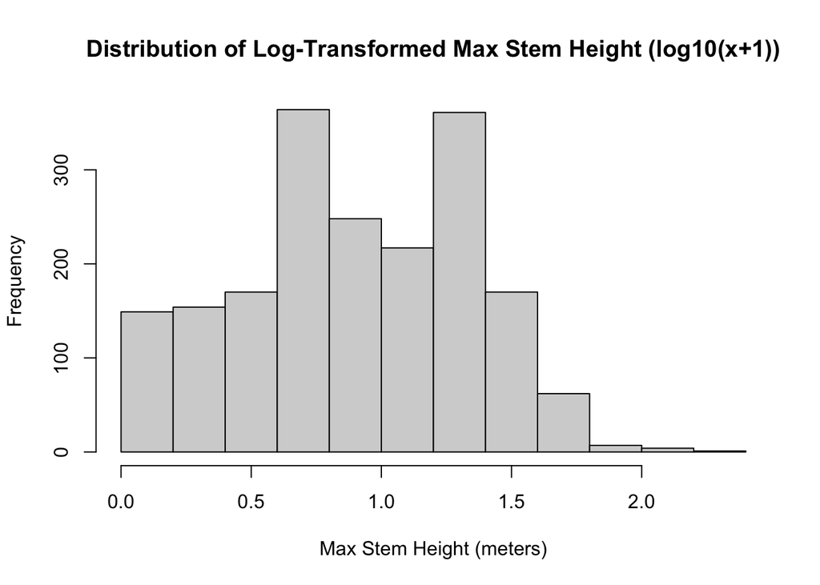

```r
hist(log10(palm_clean$MaxStemHeight_m + 1),
    main = paste("Distribution of Log-Transformed Max Stem Height (log10(x+1))"),
    xlab = "Max Stem Height (meters)", ylab = "Frequency")
```

The shape of this first histogram is very skewed to the right, with a majority of the data sitting in the first bins betweeen 0 and 50, probably because this variable has so much variation between 0 and 170m, with a lot sitting between 0 and 1m.

This second histogram makes looking at the data much more readable. Because there are a lot of species with a value of 0, adding +1 in the logarithmic function stops you from getting an undefined when putting it into a logarithm.

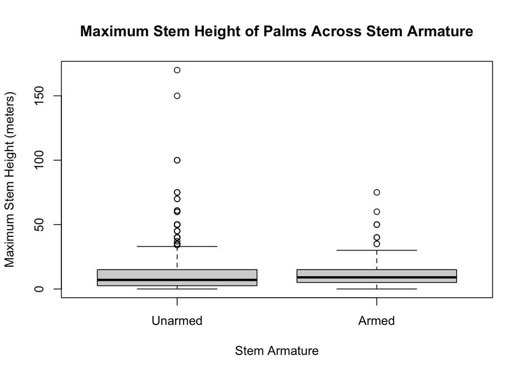

```r
# 4.2: Boxplot of stem height by armature
boxplot(palm_clean$MaxStemHeight_m ~ palm_clean$StemArmed,
     data = palm_clean,
     main = paste("Maximum Stem Height of Palms Across Stem Armature"),
     xlab = "Stem Armature", ylab = "Maximum Stem Height (meters)")
```

Looking at the boxplot, it is hard to tell but I believe the Armed palms are, on average slighter taller than the Unarmed, thought the Unarmed category has many outliers that are much taller than the average armed palm.

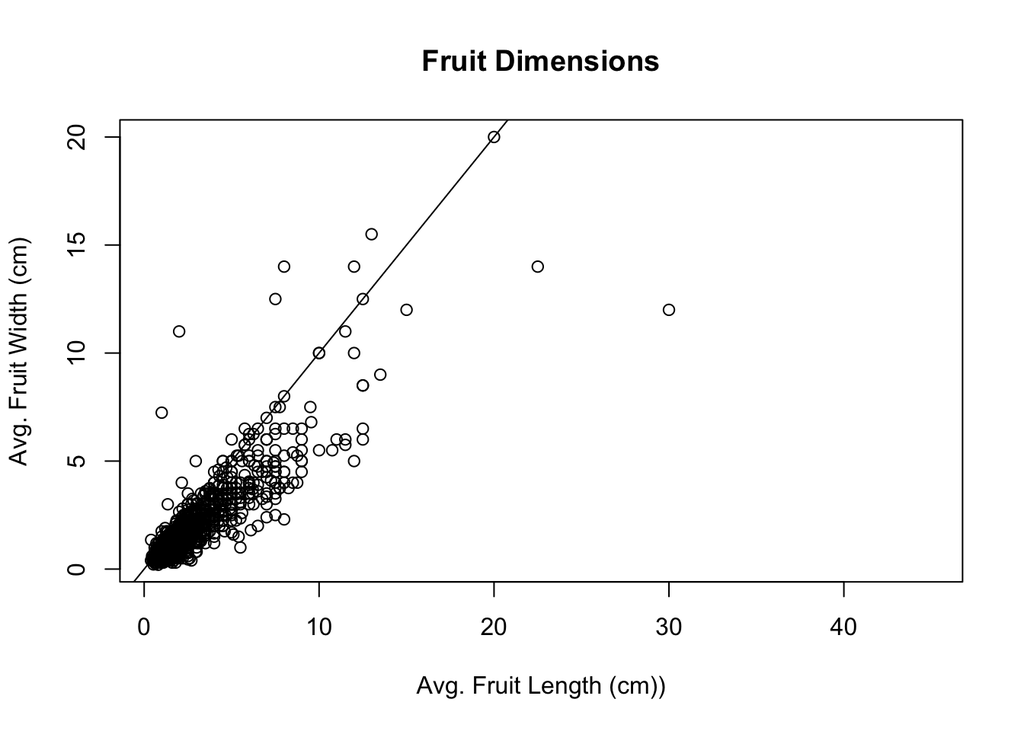

```r
# 4.3: Scatterplot of fruit dimensions
plot(palm_clean$AverageFruitLength_cm, palm_clean$AverageFruitWidth_cm,
main = paste("Fruit Dimensions"), xlab = "Avg. Fruit Length (cm))",
ylab = "Avg. Fruit Width (cm)", abline(a = 0, b = 1))
```

```r
cor(palm_clean$AverageFruitLength_cm, palm_clean$AverageFruitWidth_cm,
use = "complete.obs")
```

```
[1] 0.8781388
```

```r
# the correlation is 0.878
```

If a species is above the line, that means the fruit width of that species is higher than the length. In contrast, if the species is below the line, that means the fruit length is higher than the width.

## Part 5: Reflection

1. The biggest data quality issue I found was the number of missing values there were for a variety of the variables in the palm data. Additionally, there were also such a large number of variable that did not appear as important to analyze (such as PalmTribem PalmSumfamily, accSpecies, etc) that were distractions from numerical data that could be analyzed. Choosing to keep a certain group of variables allowed for less variables to deal with and look at, as well as removing some of the variables that had the most missing values, which would probably produce a biased result.
2. I was surprised that so many of the palm species had such a small maximum stem height, as I have always considered palm plants to be pretty tall. Secondly, I was interested in the pretty high correlation that has occurred between fruit length and fruit width, perhaps indicating some kind of growth pattern specific to palms.
3. Rendering in the Quarto Document helps with 1) If the code is totally reproducible as it runs without error or local storage as the document renders, and 2) Helps catch what formatting errors you should change, since you can see the code running off the document causing some writing to be erased from the final PDF.